# TP2 - Correction

Traitement des données

INTECHMER - CT2 GEM/PVRM

## Chargement des librairies

```r
library(tidyverse)
library(readxl)
library(scales)
```

## Importation des données

Les données proviennent du site https://data.gouv.fr et sont disponibles sur [cette page](https://www.data.gouv.fr/fr/datasets/resultat-des-peches-electriques/).

```r
donnees = read_excel("Exploitations_Basse-normandie.xls",
                     sheet = 2) # ou sheet = "nom_feuille"
```

### Affichage des dix premières lignes

```r
knitr::kable(head(donnees, 10))
```

| Date de pêche | Code station Sandre | Code station Onema | Localisation | Abscisse Station(Lambert 93) | Ordonnée Station(Lambert 93) | Ordonnée (Lambert II)…7 | Ordonnée (Lambert II)…8 | Code point) | Abscisse Point(Lambert 93)…10 | Abscisse Point(Lambert 93)…11 | Numéro de l’opération | Département | Code Insee | Nom de la commune | Code hydrographique générique du cours d’eau | Nom usuel du cours d’eau | Surface m² | Nom usuel de l’espèce | Code Onema de l ’espèce | Effectif (ind.) | Masse (g) | Densite en nombre(ind./100 m²) | Densité en masse (g/100 m²) | Nombre de passage | Methode de Prospection | Moyen de Prospection |
| --- | --- | --- | --- | --- | --- | --- | --- | --- | --- | --- | --- | --- | --- | --- | --- | --- | --- | --- | --- | --- | --- | --- | --- | --- | --- | --- |
| 1979-10-25 | NA | 03140002 | L’Aure à Mandeville-en-bessin | 0 | 0 | 362679 | 2483981 | NA | 0 | 0 | 19010000032 | 14 | 14397 | MANDEVILLE-EN-BESSIN | I4–0210 | L’Aure | 750 | Loche franche | LOF | 2 | 18.0 | 0.2666667 | 2.400000 | 1 | Complète | A pied |
| 1979-10-25 | NA | 03140002 | L’Aure à Mandeville-en-bessin | 0 | 0 | 362679 | 2483981 | NA | 0 | 0 | 19010000032 | 14 | 14397 | MANDEVILLE-EN-BESSIN | I4–0210 | L’Aure | 750 | Goujon | GOU | 4 | 38.0 | 0.5333333 | 5.066667 | 1 | Complète | A pied |
| 1979-10-25 | NA | 03140002 | L’Aure à Mandeville-en-bessin | 0 | 0 | 362679 | 2483981 | NA | 0 | 0 | 19010000032 | 14 | 14397 | MANDEVILLE-EN-BESSIN | I4–0210 | L’Aure | 750 | Gardon | GAR | 36 | 5311.2 | 4.8000000 | 708.160000 | 1 | Complète | A pied |
| 1979-10-25 | NA | 03140002 | L’Aure à Mandeville-en-bessin | 0 | 0 | 362679 | 2483981 | NA | 0 | 0 | 19010000032 | 14 | 14397 | MANDEVILLE-EN-BESSIN | I4–0210 | L’Aure | 750 | Brochet | BRO | 4 | 663.6 | 0.5333333 | 88.480000 | 1 | Complète | A pied |
| 1979-10-25 | NA | 03140002 | L’Aure à Mandeville-en-bessin | 0 | 0 | 362679 | 2483981 | NA | 0 | 0 | 19010000032 | 14 | 14397 | MANDEVILLE-EN-BESSIN | I4–0210 | L’Aure | 750 | Anguille d’Europe | ANG | 74 | 5500.0 | 9.8666667 | 733.333333 | 1 | Complète | A pied |
| 1979-10-24 | NA | 03140003 | La Drome à Castillon | 0 | 0 | 371796 | 2472582 | NA | 0 | 0 | 19010000033 | 14 | 14140 | CASTILLON | I45-0420 | La Drome | 1440 | Vairon | VAI | 320 | 832.0 | 22.2222222 | 57.777778 | 1 | Complète | A pied |
| 1979-10-24 | NA | 03140003 | La Drome à Castillon | 0 | 0 | 371796 | 2472582 | NA | 0 | 0 | 19010000033 | 14 | 14140 | CASTILLON | I45-0420 | La Drome | 1440 | Truite de riviere | TRF | 11 | 1134.0 | 0.7638889 | 78.750000 | 1 | Complète | A pied |
| 1979-10-24 | NA | 03140003 | La Drome à Castillon | 0 | 0 | 371796 | 2472582 | NA | 0 | 0 | 19010000033 | 14 | 14140 | CASTILLON | I45-0420 | La Drome | 1440 | Loche franche | LOF | 39 | 171.0 | 2.7083333 | 11.875000 | 1 | Complète | A pied |
| 1979-10-24 | NA | 03140003 | La Drome à Castillon | 0 | 0 | 371796 | 2472582 | NA | 0 | 0 | 19010000033 | 14 | 14140 | CASTILLON | I45-0420 | La Drome | 1440 | Chabot | CHA | 105 | 336.0 | 7.2916667 | 23.333333 | 1 | Complète | A pied |
| 1979-10-24 | NA | 03140003 | La Drome à Castillon | 0 | 0 | 371796 | 2472582 | NA | 0 | 0 | 19010000033 | 14 | 14140 | CASTILLON | I45-0420 | La Drome | 1440 | Anguille d’Europe | ANG | 13 | 5510.0 | 0.9027778 | 382.638889 | 1 | Complète | A pied |

## Indiquer quelques éléments sur ces données

- Etendue des dates de collecte des informations
- Nombre de stations Sandre et Onema
- Nombre de communes
- Nombre d’espèces

Pour avoir ces informations, on peut procéder item par item, comme ci-dessous

```r
min(donnees$`Date de pêche`) # et pareil avec max()
```

```
## [1] "1979-10-23 UTC"
```

```r
# unique() supprime les doublons
# length() renvoie la taille du vecteur (donc le nombre de stations Sandre ici)
donnees$`Code station Sandre` %>%
  unique() %>%
  length()
```

```
## [1] 260
```

Et on fait pareil donc avec `Code Station Onema` et `Nom usuel de l'espèce`.

Au final, on peut tout faire en une seule opération, comme ci-dessous :

```r
donnees %>%
  summarise(
    DateMin = min(`Date de pêche`),
    DateMax = max(`Date de pêche`),
    NbStationsSANDRE = n_distinct(`Code station Sandre`),
    NbStationsONEMA = n_distinct(`Code station Onema`),
    NbEspeces = n_distinct(`Nom usuel de l'espèce`)
  ) %>%
  t() %>% # Permet de transposer une matrice (lignes en colonnes et inversement)
  knitr::kable()
```

| DateMin | 1979-10-23 |
| --- | --- |
| DateMax | 2004-10-14 |
| NbStationsSANDRE | 260 |
| NbStationsONEMA | 344 |
| NbEspeces | 43 |

## Représenter, à l’aide d’un diagramme en barres, le nombre de pèches pour chaque espèce

En ne tenant pas compte du décompte de chaque espèce (affichage par ordre alphabétique). L’affichage à l’horizontal permet de mieux lire le nom des espèces, car ceux-ci sont un peu longs parfois.

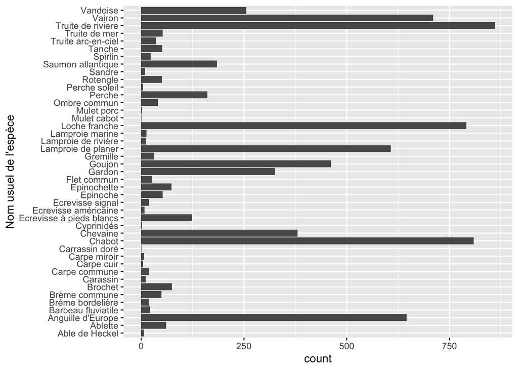

```r
ggplot(donnees, aes(y = `Nom usuel de l'espèce`)) +
  geom_bar()
```

Dans un tel graphique, il est d’usage de trier par ordre décroissant du décompte.

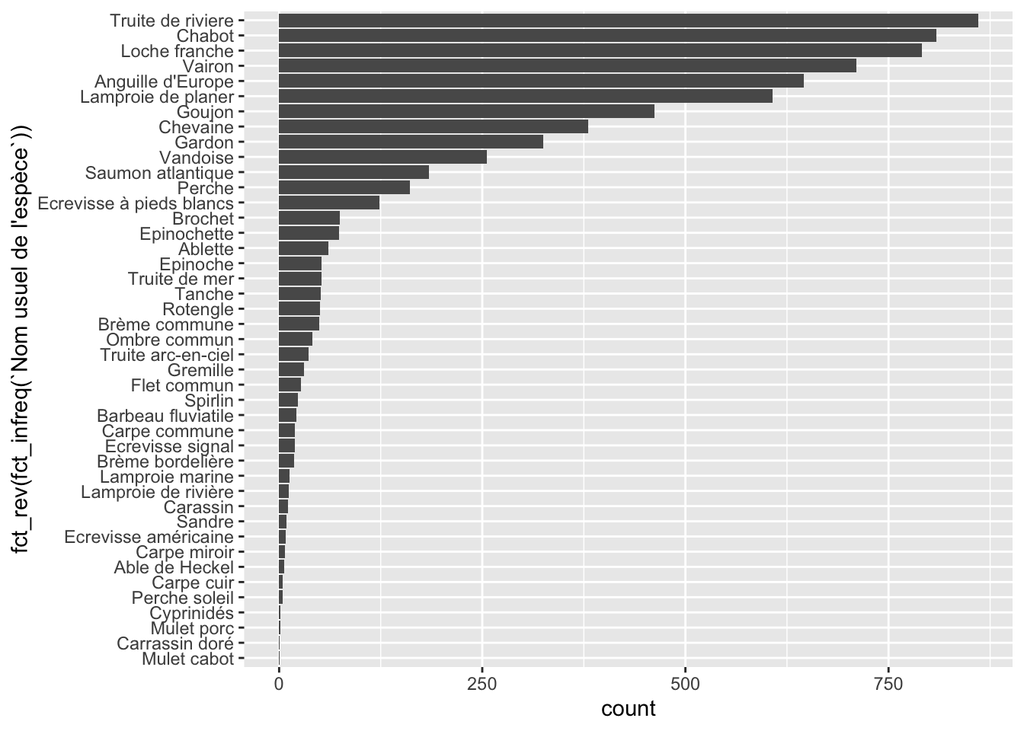

```r
ggplot(donnees, aes(y = fct_rev(fct_infreq(`Nom usuel de l'espèce`)))) +
  geom_bar()
```

Et en poussant la réflexion, on peut vouloir une couleur en fonction du nombre. Il faut déjà faire un calcul préalable pour le faire.

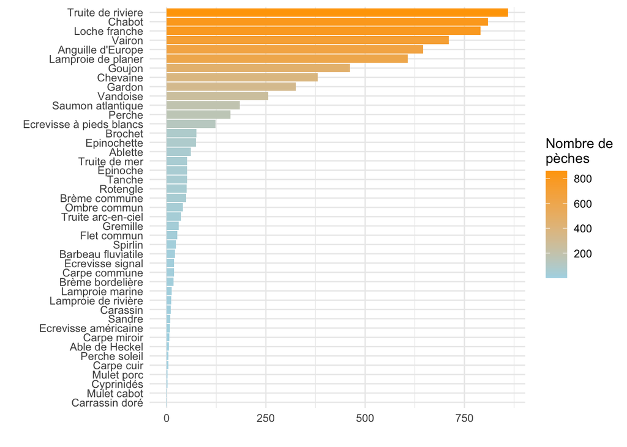

```r
temp = donnees %>%
  group_by(`Nom usuel de l'espèce`) %>%
  summarise(n = n())

ggplot(temp, aes(x = n, y = fct_reorder(`Nom usuel de l'espèce`, n), fill = n)) +
  geom_bar(stat = "identity") +
  theme_minimal() +
  labs(x = "", y = "", fill = "Nombre de\npèches") +
  scale_fill_gradient(low = "lightblue", high = "orange")
```

## Représenter, à l’aide de diagrammes circulaires :

### la part de chaque méthode de prospection

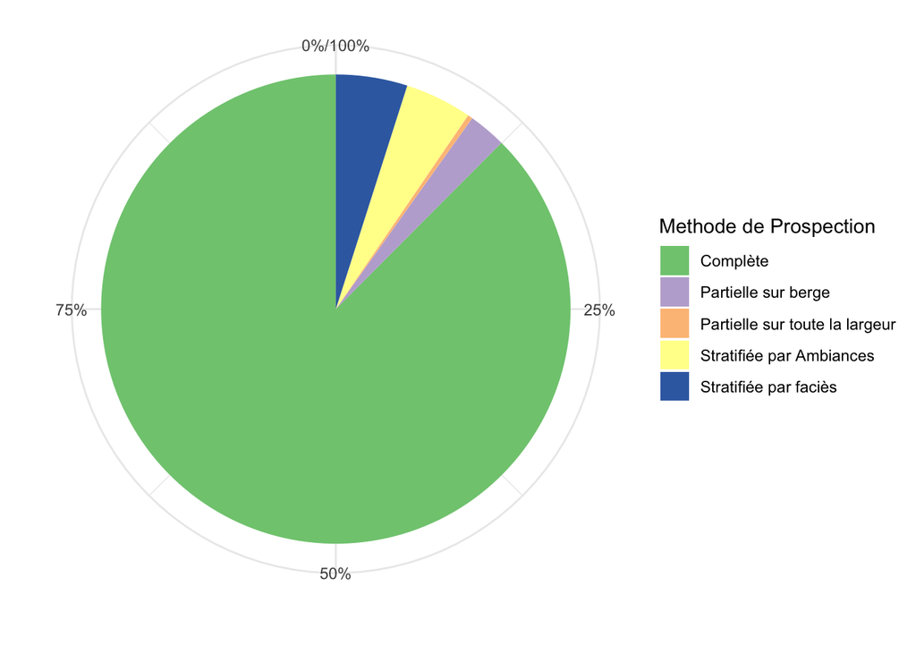

```r
ggplot(donnees, aes(x = "", fill = `Methode de Prospection`)) +
  geom_bar(position = "fill") +
  coord_polar(theta = "y") +
  scale_y_continuous(labels = percent) +
  scale_fill_brewer(palette = "Accent") +
  theme_minimal() +
  labs(x = "", y = "")
```

### la part de chaque moyen de prospection

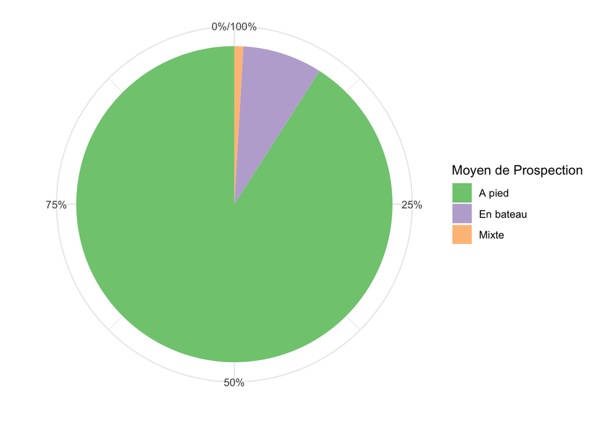

```r
ggplot(donnees, aes(x = "", fill = `Moyen de Prospection`)) +
  geom_bar(position = "fill") +
  coord_polar(theta = "y") +
  scale_y_continuous(labels = percent) +
  scale_fill_brewer(palette = "Accent") +
  theme_minimal() +
  labs(x = "", y = "")
```

## Représenter, pour chaque département, avec des graphiques adaptés :

### le nombre de communes

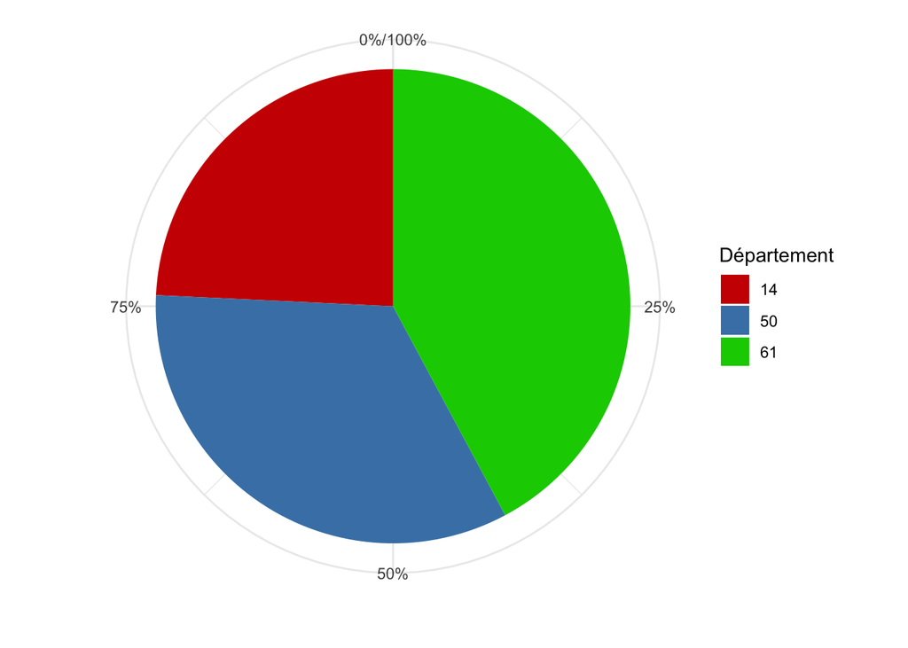

```r
temp2 = donnees %>%
  group_by(Département) %>%
  summarise(nbCommunes = n_distinct(`Code Insee`))

ggplot(temp2, aes(x = "", y = nbCommunes, fill = Département)) +
  geom_bar(stat = "identity", position = "fill") +
  coord_polar(theta = "y") +
  scale_y_continuous(labels = percent) +
  scale_fill_manual(values = c("red3", "steelblue", "green3")) +
  theme_minimal() +
  labs(x = "", y = "")
```

### le nombre total de pèches

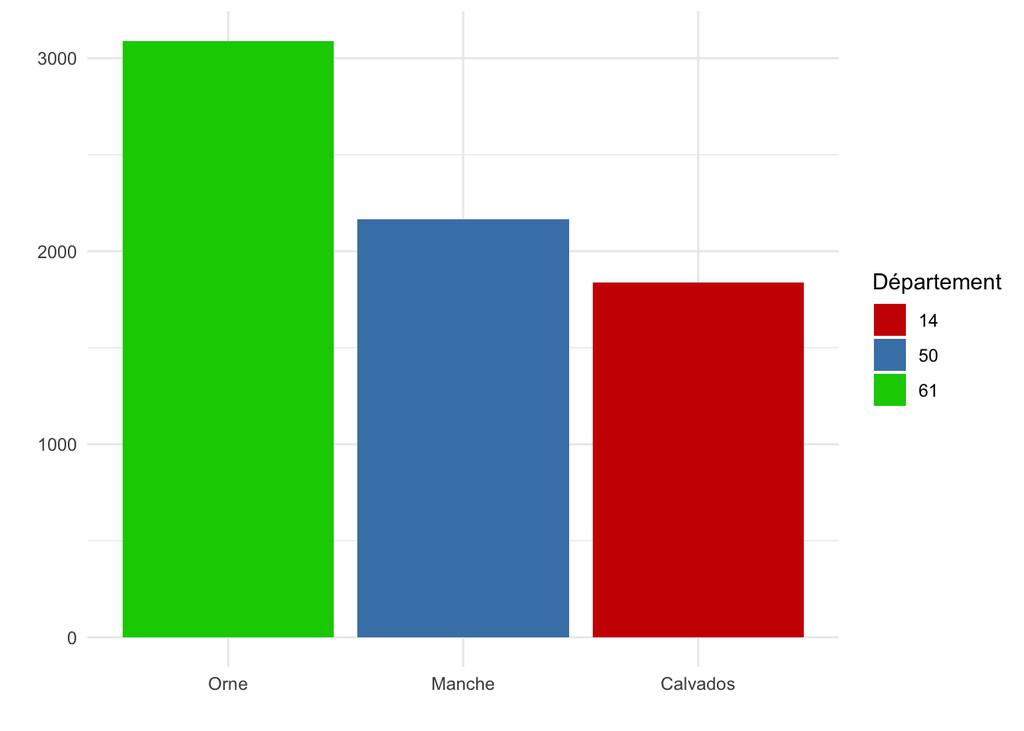

```r
temp3 = donnees %>%
  group_by(Département) %>%
  summarise(nbPeches = n())

ggplot(temp3, aes(x = fct_reorder(Département, nbPeches, .desc = TRUE),
                  y = nbPeches, fill = Département)) +
  geom_bar(stat = "identity") +
  scale_fill_manual(values = c("red3", "steelblue", "green3")) +
  scale_x_discrete(labels = c("Orne", "Manche", "Calvados")) +
  theme_minimal() +
  labs(x = "", y = "")
```

### le nombre total de pèches par année

```r
temp4 = donnees %>%
  mutate(annee = year(`Date de pêche`)) %>%
  group_by(Département, annee) %>%
  summarise(nbPeches = n())
```

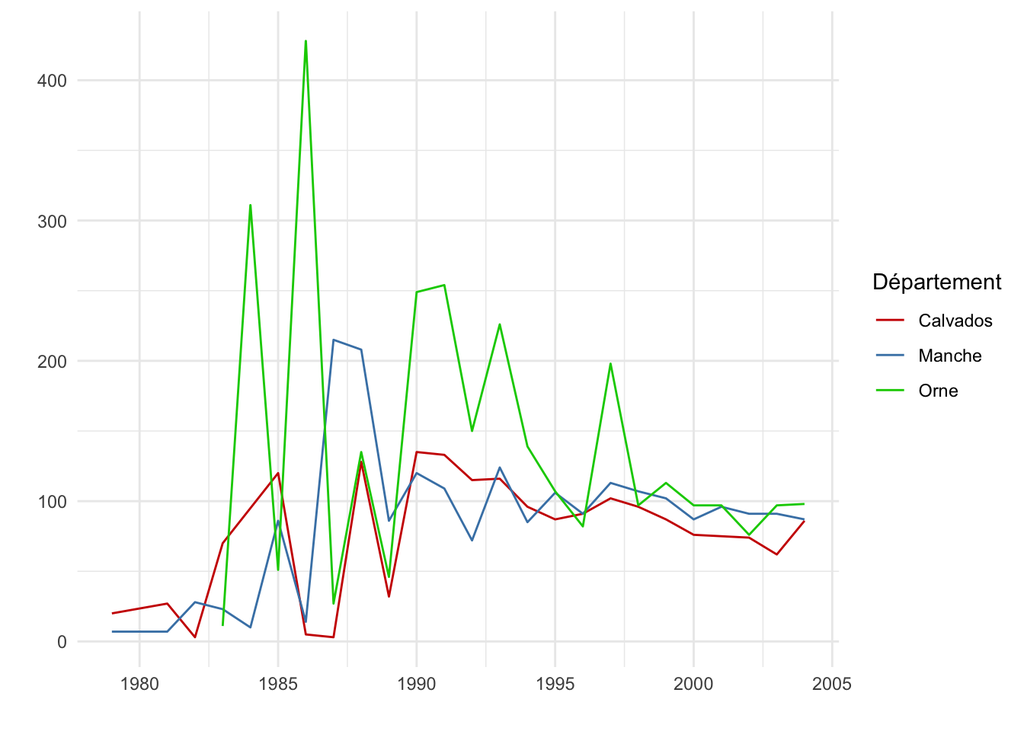

```r
ggplot(temp4, aes(x = annee,
                  y = nbPeches, color = Département)) +
  geom_line() +
  scale_color_manual(values = c("red3", "steelblue", "green3"),
                     labels = c("Calvados", "Manche", "Orne")) +
  theme_minimal() +
  labs(x = "", y = "")
```

## Représenter la densité moyenne observée pour chaque espèce (en nombre et en masse - idéalement (bonus) sur un même graphique)

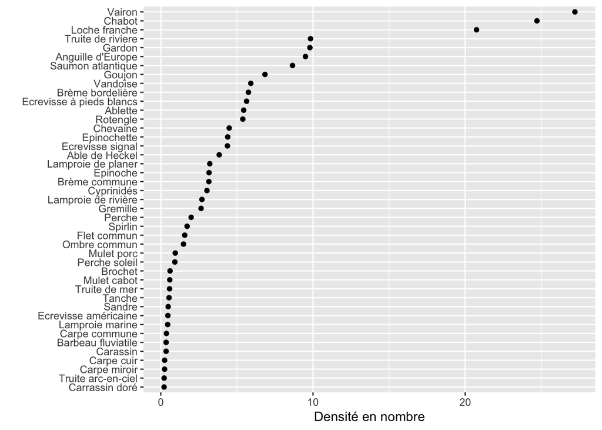

```r
temp5 = donnees %>%
  group_by(`Nom usuel de l'espèce`) %>%
  summarise(densiteNombre = mean(`Densite en nombre(ind./100 m²)`, na.rm = T),
            densiteMasse = mean(`Densité en masse (g/100 m²)`, na.rm = T))

ggplot(temp5, aes(x = densiteNombre,
                  y = fct_reorder(`Nom usuel de l'espèce`, densiteNombre))) +
  geom_point() +
  labs(x = "Densité en nombre", y = "")
```

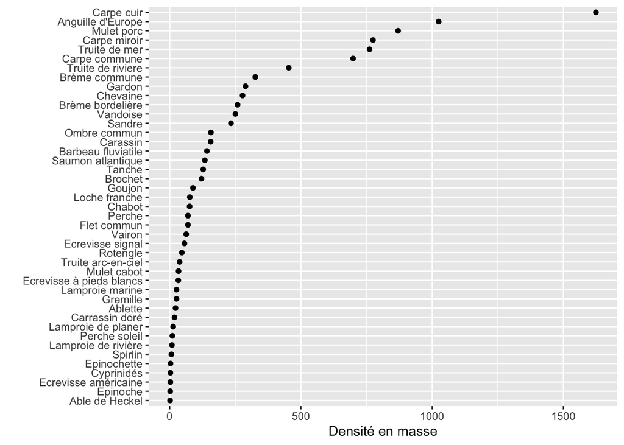

```r
ggplot(temp5, aes(x = densiteMasse,
                  y = fct_reorder(`Nom usuel de l'espèce`, densiteMasse))) +
  geom_point() +
  labs(x = "Densité en masse", y = "")
```

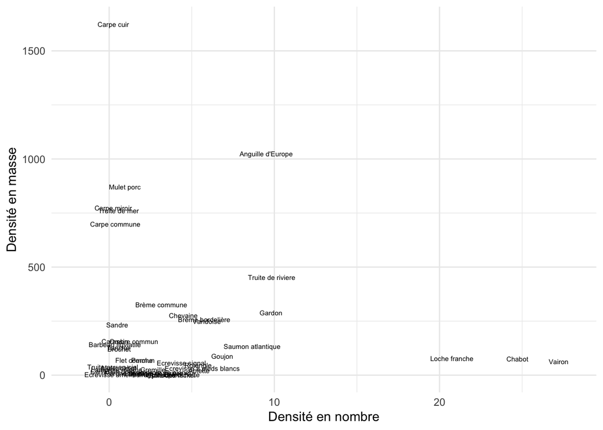

```r
ggplot(temp5, aes(x = densiteNombre, y = densiteMasse,
                  label = fct_reorder(`Nom usuel de l'espèce`, densiteMasse))) +
  geom_text(size = 2) +
  labs(x = "Densité en nombre", y = "Densité en masse") +
  xlim(-2, 28) +
  theme_minimal()
```